# R Notebook

In order to estimate the parameters of model, two methods are usually used. One is point estimation, and the other is interval estimates. The difference is that Point estimation directly give out the parameter we want, but not the Confidence interval. On the contrary, interval estimates give out the confidence interval. For point estimates, we firstly suppose the overall distribution, and set parameters according to distribution. For example, two parameters are set for the normal distribution, in writing way $N(\mu,\sigma^2)$.

For point estimates, methods of moments are preferable. If we can frame the problem in terms of a single function we can use uniroot().

e.g. there is a Poison distribution data, so we want to estimate $\lambda$, which is the only parameter for Poison.

The data table

| Lost | 0 | 1 | 2 | 3 | 4 |
| --- | --- | --- | --- | --- | --- |
| No. | 1532 | 581 | 179 | 41 | 10 |

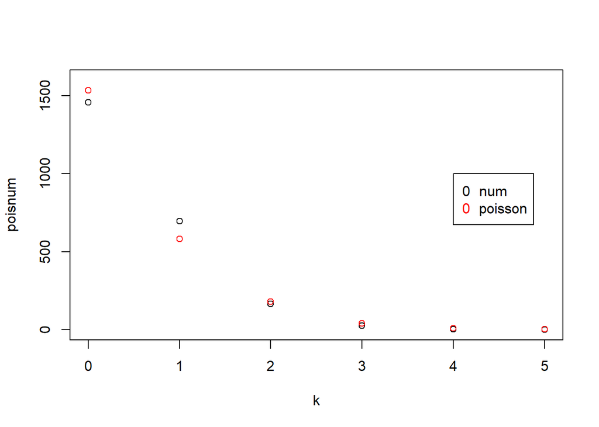

```r
num=c(rep(0:5,c(1532,581,179,41,10,4)))
lambda = mean(num)

k=0:5
ppois=dpois(k,lambda)
poisnum=ppois*length(num)
plot(k,poisnum,ylim=c(0,1600))
samplenum=as.vector(table(num))
points(k,samplenum,type="p",col=2)
legend(4,1000,legend=c("num","poisson"),col=1:2,pch="0")
```

Given that No. is poison distribution, which $\lambda$ = 0.4780571, we compare poison data and real data.

And we see the difference.

We add this to Rstudio for test.